# Aplicação de testes parámetricos aos microdados do Enem: Teste-T e Teste-Z na prática

Adauto de Galiza

18/08/2022

### Teste-T:

1. Este teste é aplicado quando quremos comparar duas amostras que são independentes entre si com n < 30. Uma “amostra” pode ser entendida como uma medida que represente uma amostra: média, médiana e etc.
2. O teste-t é considerado paramétrico, ou seja, indicado quando buscamos inferências de uma população com base na sua média pressupondo uma distribuição normal dos dados.

### Objetivo:

Iremos selecionar um colégio com até 30 registros de candidatos e aplicaremos o teste-T para verificar se há diferenças estatísticas significantes no desempenho por gênero declarado dos vestibulandos em todas as matérias do Enem.

Bibliotecas a serem utilizadas

```r
library(knitr)
library(rmarkdown)
library(RVAideMemoire) # shapiro por grupo (normalidade)
library(dplyr)
library(car) # teste de levene (homogeneidade)
library(BSDA) #z test
library(ggplot2)
```

Sobre o dataset: estamos utilizando um filtro nos microdados do Enem 2019 aplicados ao Estado do Piauí por motivos de eficiência computacional. Toda fase de extração e tramanento destes dados foram feitas em momento anterior a este relatório.

O dataset de interesse possui a seguinte estrutura:

```r
paged_table(head(vestibulando_presente))
```

|  | NU_INSCRICAO | NO_MUNICIPIO_RESIDENCIA | NU_IDADE | TP_SEXO | TP_COR_RACA | TP_NACIONALIDADE | TP_ESCOLA | TP_ENSINO | CO_ESCOLA | TP_PRESENCA_CN | TP_PRESENCA_CH | TP_PRESENCA_LC | TP_PRESENCA_MT | NOTA_CN | NOTA_CH | NOTA_LC | NOTA_MT | TP_LINGUA | TP_STATUS_REDACAO | NOTA_COMP1 | NOTA_COMP2 | NOTA_COMP3 | NOTA_COMP4 | NOTA_COMP5 | NOTA_REDACAO |
| --- | --- | --- | --- | --- | --- | --- | --- | --- | --- | --- | --- | --- | --- | --- | --- | --- | --- | --- | --- | --- | --- | --- | --- | --- | --- |
| 1 | 190001015216 | Ipiranga do Piauí | 17 | M | 2 | 1 | 3 | 1 | 15134539 | 1 | 1 | 1 | 1 | 546.9 | 507.7 | 504.1 | 654.2 | 0 | 1 | 120 | 160 | 140 | 120 | 140 | 680 |
| 4 | 190001060809 | Teresina | 17 | F | 1 | 1 | 1 | 1 | NA | 1 | 1 | 1 | 1 | 436.1 | 462.9 | 501.7 | 627.1 | 1 | 1 | 160 | 200 | 160 | 180 | 180 | 880 |
| 5 | 190001073992 | Parnaíba | 18 | F | 3 | 1 | 1 | 1 | NA | 1 | 1 | 1 | 1 | 551.6 | 560.9 | 572.4 | 581.8 | 1 | 1 | 160 | 180 | 160 | 140 | 160 | 800 |
| 6 | 190001095035 | Teresina | 20 | F | 1 | 1 | 1 | NA | NA | 1 | 1 | 1 | 1 | 553.9 | 551.8 | 596.7 | 603.4 | 1 | 1 | 160 | 160 | 160 | 160 | 160 | 800 |
| 7 | 190001095696 | Teresina | 16 | M | 3 | 1 | 2 | 1 | 22027610 | 1 | 1 | 1 | 1 | 408.4 | 507.4 | 528.2 | 505.6 | 1 | 1 | 140 | 120 | 120 | 120 | 120 | 620 |
| 8 | 190001095927 | Lagoinha do Piauí | 17 | F | 3 | 1 | 1 | 1 | NA | 1 | 1 | 1 | 1 | 420.5 | 348.4 | 523.0 | 510.0 | 1 | 1 | 140 | 120 | 120 | 120 | 100 | 600 |

Tratando e filtrando dados de interesse

```r
## Renomeando dados no banco

vestibulando_presente$TP_SEXO[vestibulando_presente$TP_SEXO == "M"] <- "Masculino"
vestibulando_presente$TP_SEXO[vestibulando_presente$TP_SEXO == "F"] <- "Feminino"
```

```r
## Verificando colégios em que n < 30

vestibulando_presente %>%
  group_by(CO_ESCOLA) %>%
  summarise(qtde = n()) %>%
  filter(qtde < 30) %>%
  arrange(desc(qtde))
```

```
## # A tibble: 568 x 2
##    CO_ESCOLA  qtde
##        <int> <int>
##  1  22014470    29
##  2  22027343    29
##  3  22027360    29
##  4  22036369    29
##  5  22072500    29
##  6  22078096    29
##  7  22100083    29
##  8  22133682    29
##  9  22137602    29
## 10  22007431    28
## # ... with 558 more rows
```

```r
## Criando novo dataset apenas com colégio aleatóriamente selecionado
colegio <- vestibulando_presente %>%
  filter(CO_ESCOLA == "22053182")

## Verificando dimensoes do novo dataset
dim(colegio)
```

```
## [1] 18 25
```

Características do teste-T:

1. Só deve ser aplicado se os dados apresentarem distribuição normal
2. Só deve ser aplicado se existir homogeneidade das amostras
3. As amostras devem ter no máximo 30 elementos (n < 30)

### Pressupostos

1. Verificando se os dados possuem distribuição normal em **todas as diciplinas**

1.1. nivel de significância = 0,05

1.2. Ho = distribuição normal se p > 0,05

1.3. Ha = sem districuição normal se p <= 0,05

```r
byf.shapiro(NOTA_CN ~ TP_SEXO, colegio)
```

```
##
##  Shapiro-Wilk normality tests
##
## data:  NOTA_CN by TP_SEXO
##
##                W p-value
## Feminino  0.8475 0.02646 *
## Masculino 0.9636 0.83262
## ---
## Signif. codes:  0 '***' 0.001 '**' 0.01 '*' 0.05 '.' 0.1 ' ' 1
```

```r
# Ciências Naturais: distribuição não-normal para o grupo "feminino"
```

```r
byf.shapiro(NOTA_CH ~ TP_SEXO, colegio)
```

```
##
##  Shapiro-Wilk normality tests
##
## data:  NOTA_CH by TP_SEXO
##
##                W p-value
## Feminino  0.9186  0.2401
## Masculino 0.9702  0.8763
```

```r
# Ciêcias Humanas: distribuição normal para ambos os gêneros
```

```r
byf.shapiro(NOTA_MT ~ TP_SEXO, colegio)
```

```
##
##  Shapiro-Wilk normality tests
##
## data:  NOTA_MT by TP_SEXO
##
##                W p-value
## Feminino  0.9292 0.33266
## Masculino 0.7859 0.06184 .
## ---
## Signif. codes:  0 '***' 0.001 '**' 0.01 '*' 0.05 '.' 0.1 ' ' 1
```

```r
# Matemática: normalidade em ambos os gêneros
```

```r
byf.shapiro(NOTA_LC ~ TP_SEXO, colegio)
```

```
##
##  Shapiro-Wilk normality tests
##
## data:  NOTA_LC by TP_SEXO
##
##                W p-value
## Feminino  0.8718 0.05524 .
## Masculino 0.9409 0.67258
## ---
## Signif. codes:  0 '***' 0.001 '**' 0.01 '*' 0.05 '.' 0.1 ' ' 1
```

```r
# Linguagens e Códigos: normalidade em ambos os gêneros
```

```r
byf.shapiro(NOTA_REDACAO ~ TP_SEXO, colegio)
```

```
##
##  Shapiro-Wilk normality tests
##
## data:  NOTA_REDACAO by TP_SEXO
##
##                W p-value
## Feminino  0.9743  0.9395
## Masculino 0.7679  0.0432 *
## ---
## Signif. codes:  0 '***' 0.001 '**' 0.01 '*' 0.05 '.' 0.1 ' ' 1
```

```r
# Redação: distribuição não-normal para grupo "masculino"

## Resultado: iremos desconsiderar comparações entre os grupos para notas de Redação e Ciências Naturais
```

2. Verificando homocedasticidade das variâncias: a variabilidade dos erros deve ser constante.

2.1) Ho = amostras homogêneas se p > 0,05

2.2) Ha = amostras heterogêneas se p <= 0,05

Obs: No teste de levene o parâmetro “center” serve para indicar qual métrica deve ser aplicada: média ou mediana.

```r
leveneTest(NOTA_CH ~ TP_SEXO, colegio, center = mean)
```

```
## Levene's Test for Homogeneity of Variance (center = mean)
##       Df F value Pr(>F)
## group  1  1.0927 0.3114
##       16
```

```r
# Ciências Humanas: amostras homogêneas
```

```r
leveneTest(NOTA_MT ~ TP_SEXO, colegio, center = mean)
```

```
## Levene's Test for Homogeneity of Variance (center = mean)
##       Df F value  Pr(>F)
## group  1  7.6478 0.01379 *
##       16
## ---
## Signif. codes:  0 '***' 0.001 '**' 0.01 '*' 0.05 '.' 0.1 ' ' 1
```

```r
# Matemática: Não há homogeneidade para nota de MT -> Necessitará de parâmetro adicional no test-t student
```

```r
leveneTest(NOTA_LC ~ TP_SEXO, colegio, center = mean)
```

```
## Levene's Test for Homogeneity of Variance (center = mean)
##       Df F value Pr(>F)
## group  1  1.4964 0.2389
##       16
```

```r
# Linguagens e Códigos: amostras homogêneas
```

### Aplicando teste-T de student

1. Ho = não há diferença entre as médias das amostras se p > 0,05
2. Ha = existe diferença entre as médias das amostras se p <= 0,05
3. Nivel de significância 0,05

```r
t.test(NOTA_CH ~ TP_SEXO, colegio, var.equal = T)
```

```
##
##  Two Sample t-test
##
## data:  NOTA_CH by TP_SEXO
## t = -0.52464, df = 16, p-value = 0.607
## alternative hypothesis: true difference in means between group Feminino and group Masculino is not equal to 0
## 95 percent confidence interval:
##  -89.53741  54.01126
## sample estimates:
##  mean in group Feminino mean in group Masculino
##                451.4769                469.2400
```

```r
# Ciências Humanas: p-value = 0.607
# Não há diferenças significativas entre Masculino e Feminino com 95% de confiança.
```

```r
# Em matemática o pressuposto de homogeneidade dos erros não foi atendido

# Nestes casos informamos o parâmetro "var.equal" = FALSE

t.test(NOTA_MT ~ TP_SEXO, colegio, var.equal = F)
```

```
##
##  Welch Two Sample t-test
##
## data:  NOTA_MT by TP_SEXO
## t = -1.3723, df = 4.6611, p-value = 0.2323
## alternative hypothesis: true difference in means between group Feminino and group Masculino is not equal to 0
## 95 percent confidence interval:
##  -222.20928   69.74467
## sample estimates:
##  mean in group Feminino mean in group Masculino
##                472.5077                548.7400
```

```r
# Matemática: p-value = 0.2323
# Não há diferenças significativas entre Masculino e Feminino com 95% de confiança.
```

```r
t.test(NOTA_LC ~ TP_SEXO, colegio, var.equal = T)
```

```
##
##  Two Sample t-test
##
## data:  NOTA_LC by TP_SEXO
## t = -0.7107, df = 16, p-value = 0.4875
## alternative hypothesis: true difference in means between group Feminino and group Masculino is not equal to 0
## 95 percent confidence interval:
##  -105.17792   52.36254
## sample estimates:
##  mean in group Feminino mean in group Masculino
##                477.8923                504.3000
```

```r
# Linguagens e Códigos: p-value = 0.4875
# Não há diferenças significativas entre Masculino e Feminino com 95% de confiança.
```

### Impressões gerais:

1. Não há diferenças estatisticamente significativas para as médias das notas de CH, MT e LC entre homens e mulheres com 95% de confiança para o colégio selecionado.
2. Por problemas de normalidade, não podemos comparar as notas de CN e Redação entre os gêneros

### Analisando Graficamente:

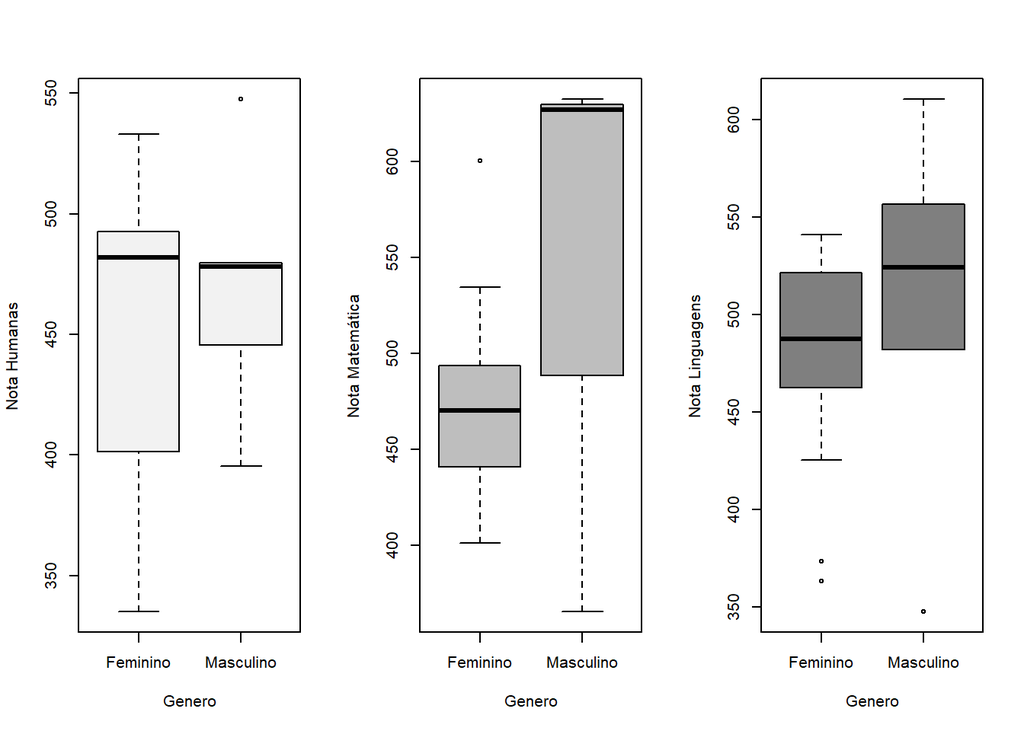

```r
par(mfrow=c(1,3))
boxplot(NOTA_CH ~ TP_SEXO, colegio, ylab = "Nota Humanas", xlab = "Genero", col = "grey95", title = "a")
boxplot(NOTA_MT ~ TP_SEXO, colegio, ylab = "Nota Matemática", xlab = "Genero", col = "grey")
boxplot(NOTA_LC ~ TP_SEXO, colegio, ylab = "Nota Linguagens", xlab = "Genero", col = "grey50")
```

### Teste-Z:

1. O teste-Z proporciona o mesmo tipo de comparação entre amostras do teste-T, porém aqui é possível aplicar para amostras maiores de 30 elementos.
2. Assim como o teste-T, teste-z também é considerado paramétrico.

### Objetivo:

Iremos filtrar do dataset apenas candidatos de escolas públicas e particulares e aplicar o teste-Z para comparar as **médias** entre os dois grupos.

Antes, precisamos fazer alguns tratamentos e filtros na base:

```r
## Renoemando registros na base de dados para pública e particular

vestibulando_presente$TP_ESCOLA[vestibulando_presente$TP_ESCOLA == 1] <- "Não Respondeu"
vestibulando_presente$TP_ESCOLA[vestibulando_presente$TP_ESCOLA == "2"] <- "Pública"
vestibulando_presente$TP_ESCOLA[vestibulando_presente$TP_ESCOLA == "3"] <- "Particular"
vestibulando_presente$TP_ESCOLA[vestibulando_presente$TP_ESCOLA == "4"] <- "Exterior"
```

```r
## Filtrando apenas candidatos de escolas públicas e particulares

escolas <- vestibulando_presente %>%
  filter(TP_ESCOLA %in% c("Pública", "Particular"))
```

### Verificando pressupostos:

1. Verificando se os dados possuem distribuição normal em **todas as diciplinas**

1.1. nivel de significância = 0,05

1.2. Ho = distribuição normal se p > 0,05

1.3. Ha = sem districuição normal se p <= 0,05

Problema: o teste de shapiro só pode ser aplicado para n entre 3 e 5000 amostras.

Solução alternativa é verificar a normalidade por histogramas e Q-Q Plot: sempre existe a imprecisão de utilizar gráficos para este objetivo

Iremos utilizar o ggplot para histogramas:

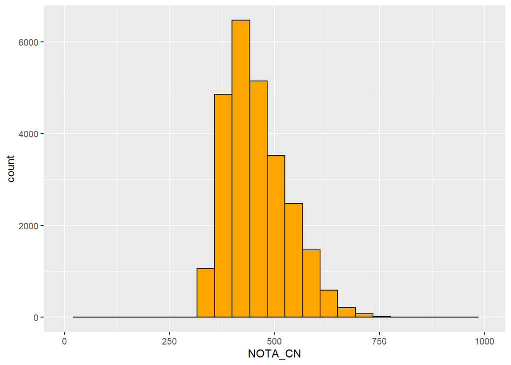

```r
# Ciências naturais:
escolas %>%
  ggplot(aes(x = NOTA_CN)) +
  geom_histogram(binwidth=42, color = "black" , fill = "orange") +
  scale_x_continuous(limits = c(0, 1000))
```

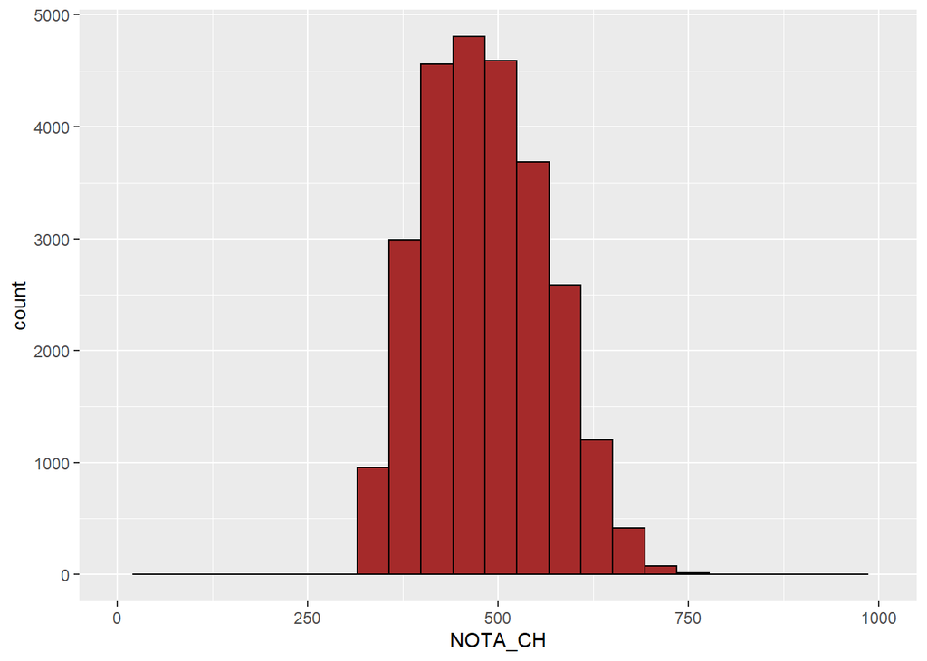

```r
# Ciências humanas:
escolas %>%
  ggplot(aes(x = NOTA_CH)) +
  geom_histogram(binwidth=42, color = "black" , fill = "brown") +
  scale_x_continuous(limits = c(0, 1000))
```

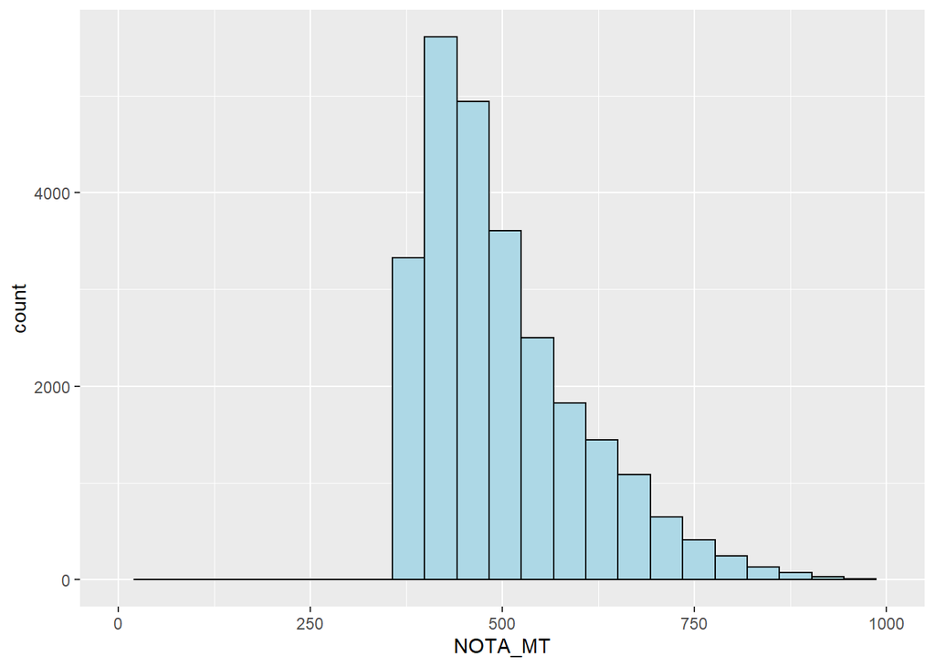

```r
# Matemática:
escolas %>%
  ggplot(aes(x = NOTA_MT)) +
  geom_histogram(binwidth=42, color = "black" , fill = "light blue") +
  scale_x_continuous(limits = c(0, 1000))
```

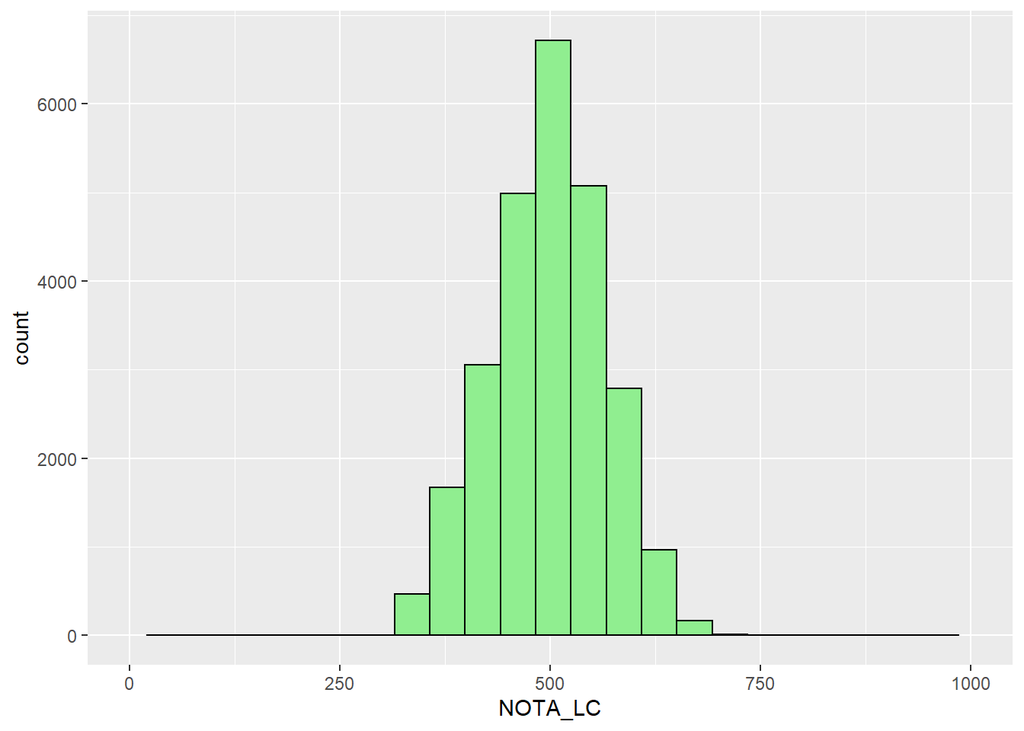

```r
# Linguagens e Códigos:
escolas %>%
  ggplot(aes(x = NOTA_LC)) +
  geom_histogram(binwidth=42, color = "black" , fill = "light green") +
  scale_x_continuous(limits = c(0, 1000))
```

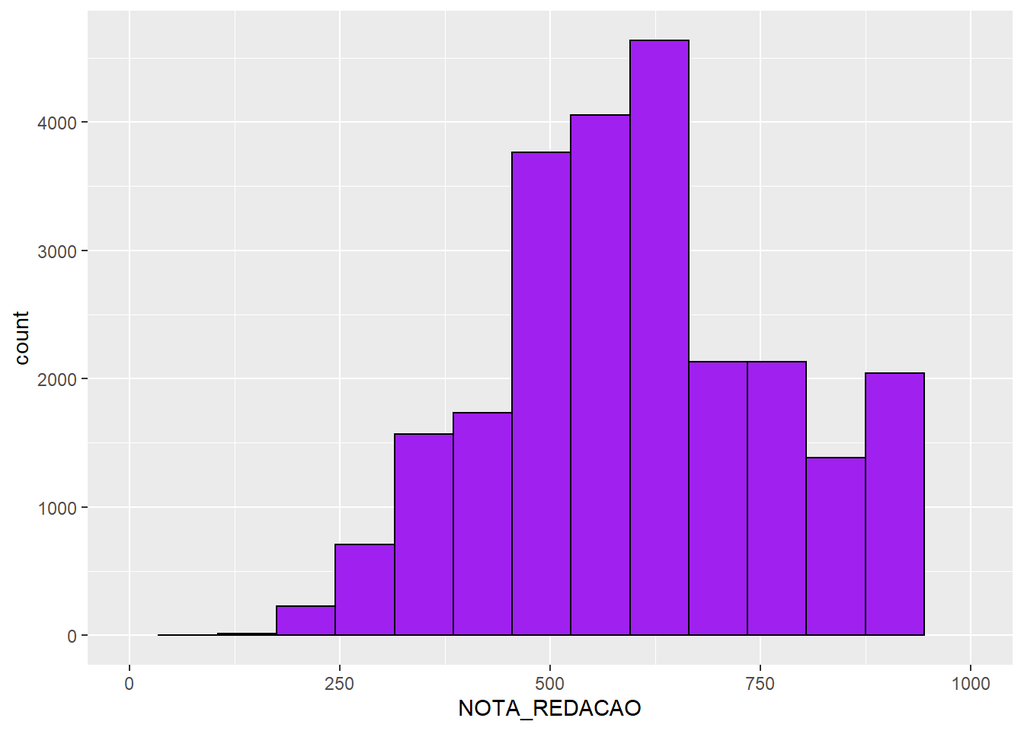

```r
# Redação:
escolas %>%
  ggplot(aes(x = NOTA_REDACAO)) +
  geom_histogram(binwidth=70, color = "black" , fill = "purple") +
  scale_x_continuous(limits = c(0, 1000))
```

### Impressões:

1. Alguns dadados aproximam-se levemente de uma distribuição normal
2. Porém, não podemos ter certeza da normalidade.

Logo, iremos comparar os histogramas com o Q-Q plot de cada nota. Atestamos normalidade se **os pontos estiverem planos sob a reta de refrência**

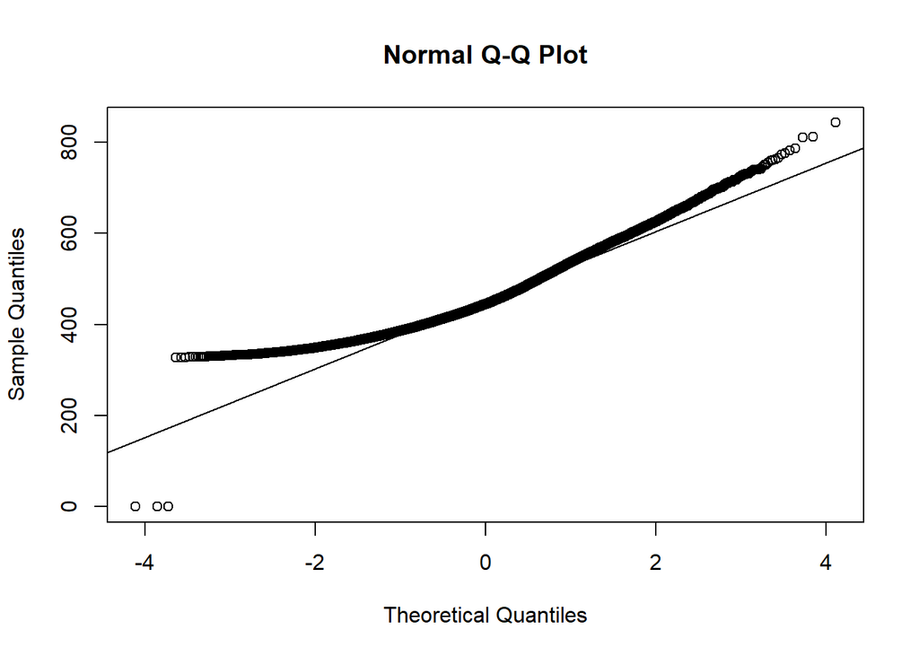

```r
# Ciências naturais:
qqnorm(escolas$NOTA_CN)
qqline(escolas$NOTA_CN)
```

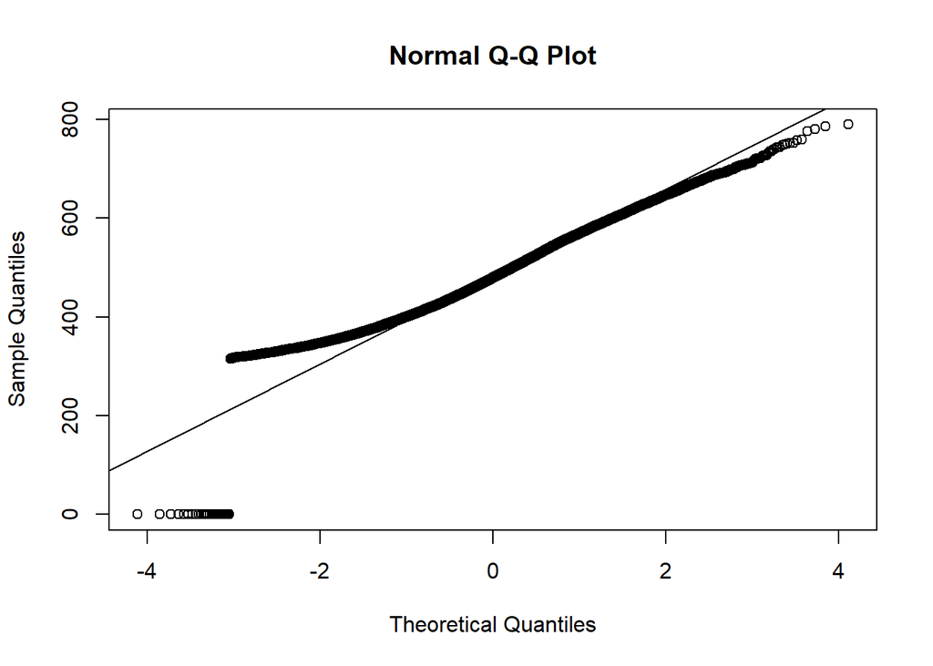

```r
# Ciências humanas:
qqnorm(escolas$NOTA_CH)
qqline(escolas$NOTA_CH)
```

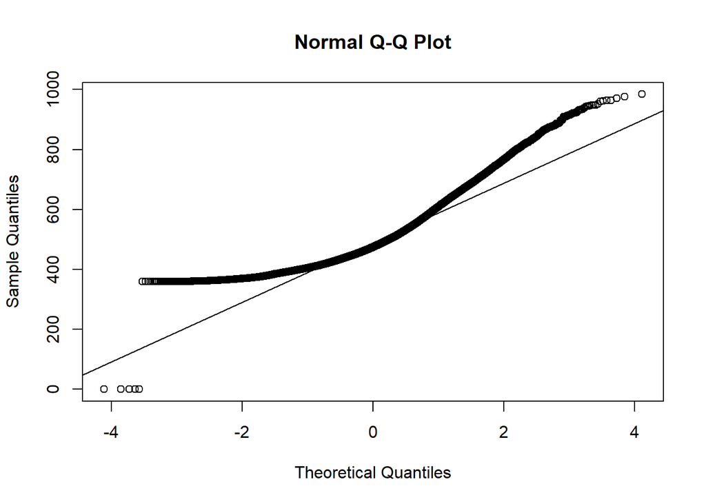

```r
# Matemática:
qqnorm(escolas$NOTA_MT)
qqline(escolas$NOTA_MT)
```

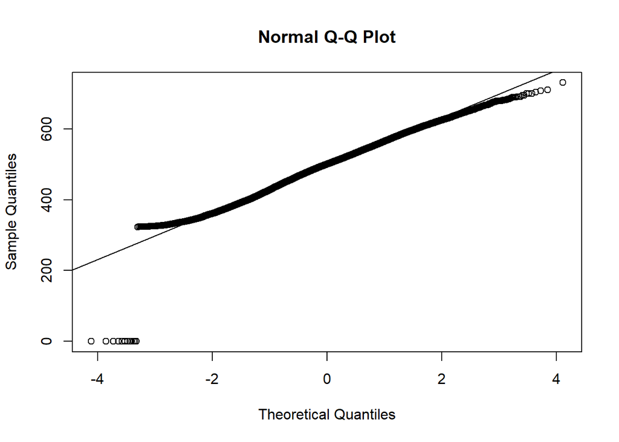

```r
# Linguagens e Códigos:
qqnorm(escolas$NOTA_LC)
qqline(escolas$NOTA_LC)
```

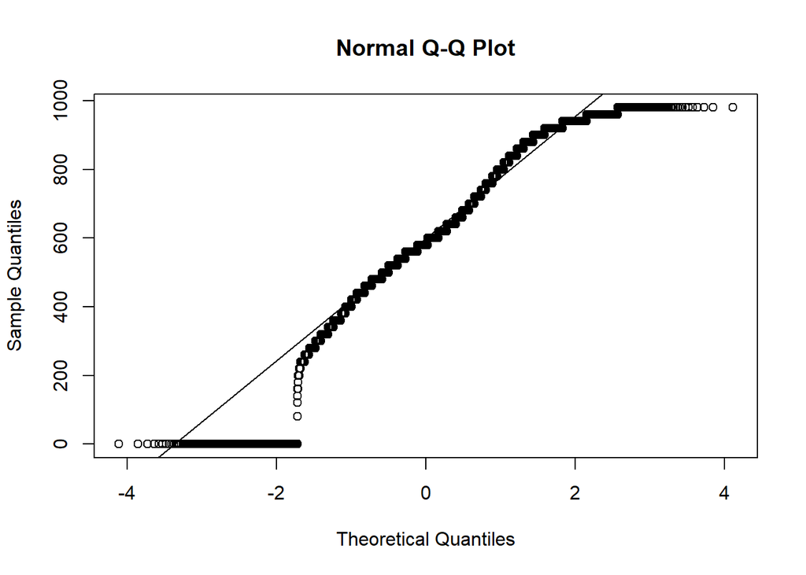

```r
# Redação:
qqnorm(escolas$NOTA_REDACAO)
qqline(escolas$NOTA_REDACAO)
```